# bayesian

## Bayessian search. Is it the best way to tune your hyperparameters?

As you may know, every machine learning model, whether it's a tree based one, or a deep neural network consists of trainable parameteres (weights, bias etc.) and hyperparameteres that can not be optimized during the training process. After acquiring a dataset, you have to initialize and optimize the weights of every layer, or just optimizing (if you use *transfer learning*). This process is computationaly expensive for a set of hyperparameters $ (h_1, h_2, ...h_n) $ and we have to find a way of performing fewer runs. In this article, we will briefly talk about 3 ways of hyperparameter tunning, with the final accuracy and the runtime.

## Model and Dataset

For this article, we've chosed a light [dataset](https://raw.githubusercontent.com/ricardoscr/UW-Data-Science-Certificate/master/02-Methods/CADairyProduction.csv) regarding the dairy products industry. We will forecast the monthly milk production based on past quantities of Cotage cheese, Icecream and fat. Because the values varies through time we have to deal with a time series subject. Therefore, we'll use a tree based model, [xgboost](https://xgboost-clone.readthedocs.io/en/latest/) and try to optimize its hyperparameters.

```python
import xgboost as xgb
import pandas as pd
import numpy as np
import matplotlib.pyplot as plt
from datetime import datetime

from skopt import BayesSearchCV
from sklearn.model_selection import train_test_split, GridSearchCV, RandomizedSearchCV, \
                                    TimeSeriesSplit
from sklearn.preprocessing import LabelEncoder
from sklearn.metrics import mean_absolute_error, explained_variance_score
```

The dataset consists of one table, let's visualize it using pandas library and matplotlib.

```python
dataset_filename = 'CADairyProduction.csv'
dataset = pd.read_csv(dataset_filename)
dataset.head()
```

|  | Year | Month | Cotagecheese.Prod | Icecream.Prod | Milk.Prod | N.CA.Fat.Price | Month.Count | monthNumSqred | monthNumCubed |
| --- | --- | --- | --- | --- | --- | --- | --- | --- | --- |
| 0 | 1995 | Jan | 4.370 | 51.595 | 2.112 | 0.9803 | 1 | 1 | 1 |
| 1 | 1995 | Feb | 3.695 | 56.086 | 1.932 | 0.8924 | 2 | 4 | 8 |
| 2 | 1995 | Mar | 4.538 | 68.453 | 2.162 | 0.8924 | 3 | 9 | 27 |
| 3 | 1995 | Apr | 4.280 | 65.722 | 2.130 | 0.8967 | 4 | 16 | 64 |
| 4 | 1995 | May | 4.470 | 73.730 | 2.227 | 0.8967 | 5 | 25 | 125 |

We will use **Month.Count** as index drop the last 2 columns which represents the squared and the cubed value of the month number.

```python
columns_to_drop = ['monthNumSqred', 'monthNumCubed']
for col in columns_to_drop:
    dataset.pop(col)

year_column = 'Year'
month_column = 'Month'
timestamp = 'Month.Count'
cheese_column = 'Cotagecheese.Prod'
icecream_column = 'Icecream.Prod'
milk_column = 'Milk.Prod'
fat_column = 'N.CA.Fat.Price'
```

```python
dataset.head()
```

|  | Year | Month | Cotagecheese.Prod | Icecream.Prod | Milk.Prod | N.CA.Fat.Price | Month.Count |
| --- | --- | --- | --- | --- | --- | --- | --- |
| 0 | 1995 | Jan | 4.370 | 51.595 | 2.112 | 0.9803 | 1 |
| 1 | 1995 | Feb | 3.695 | 56.086 | 1.932 | 0.8924 | 2 |
| 2 | 1995 | Mar | 4.538 | 68.453 | 2.162 | 0.8924 | 3 |
| 3 | 1995 | Apr | 4.280 | 65.722 | 2.130 | 0.8967 | 4 |
| 4 | 1995 | May | 4.470 | 73.730 | 2.227 | 0.8967 | 5 |

Now, one of the most important step is understanding the data and "make a lot of plots". We can easily notice that the icecream production has higher values than the otheres. Therefore we decided to plot it in another figure.

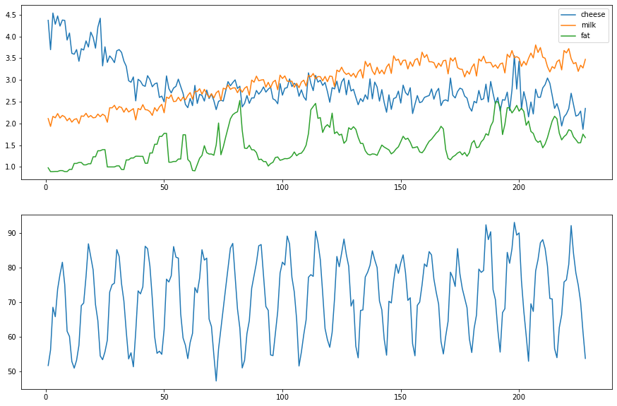

```python
fig, (ax1, ax2) = plt.subplots(2, 1, sharey=False)
fig.set_figheight(10)
fig.set_figwidth(15)

ax1.plot(dataset[timestamp], dataset[cheese_column])
ax1.plot(dataset[timestamp], dataset[milk_column])
ax1.plot(dataset[timestamp], dataset[fat_column])
ax1.legend(['cheese', 'milk', 'fat'])

ax2.plot(dataset[timestamp], dataset[icecream_column])
```

Here we can see a seasonal patern inside the icecream graph. The milk is week corelated in the begining, but with time and on the test side may work relatively well.  
The next step is to encode the month column using a LabelEncoder from [sklearn](https://scikit-learn.org/stable/).

```python
encoder = LabelEncoder()

month_column_enc = month_column + '.enc'
dataset[month_column_enc] = encoder.fit_transform(dataset[month_column])
```

```python
features = [timestamp, year_column, month_column_enc, cheese_column, icecream_column, \
                 fat_column]
features_scaled = [col + '.scaled' for col in features]
milk_column_scaled = milk_column + '.scaled'
```

Another sklearn tool will help us spliting the data into train and test. Test will be 15% of the data and because it's a time series problem, we'll not shuffle the lines.

```python
X_train, X_test, y_train, y_test = train_test_split(dataset[features],
                                                    dataset[milk_column],
                                                    test_size=0.15,
                                                    shuffle=False)
```

```python
y_train = pd.DataFrame(y_train, columns=[milk_column])
y_test = pd.DataFrame(y_test, columns=[milk_column])
```

Now we'll scale the other numerical features, manually simulating a [MinMaxScaller](https://scikit-learn.org/stable/modules/generated/sklearn.preprocessing.MinMaxScaler.html). Precisely, we'll get the maximum and minimum values from the training set and apply the formula with these parameteres on both the training and test set.

```python
X_minimum = X_train.min()
X_maximum = X_train.max()

y_minimum = y_train.min().values[0]
y_maximum = y_train.max().values[0]
```

```python
X_train[features_scaled] = (X_train[features] - X_minimum[features]) / \
                           (X_maximum[features] - X_minimum[features])

X_test[features_scaled] = (X_test[features] - X_minimum[features]) / \
                          (X_maximum[features] - X_minimum[features])

y_train[milk_column_scaled] = (y_train[milk_column] - y_minimum) / (y_maximum - y_minimum)
y_test[milk_column_scaled] = (y_test[milk_column] - y_minimum) / (y_maximum - y_minimum)
```

```python
X_train_arr = np.array(X_train[features_scaled])
y_train_arr = np.array(y_train[milk_column_scaled])

X_test_arr = np.array(X_test[features_scaled])
y_test_arr = np.array(y_test[milk_column_scaled])
```

The following search methods require [K-Fold Cross Validation](https://machinelearningmastery.com/k-fold-cross-validation/). However, the regular one does not fit on time series subjects, because that means predicting the past behaviour based on future events, and this may interfere with the pattern that our model tries to understand. So, we'll use a [TimeSeriesSplit](https://scikit-learn.org/stable/modules/generated/sklearn.model_selection.TimeSeriesSplit.html) which folds the dataset only from right to left (future through past).

[figure not shown]

```python
xg_reg = xgb.XGBRegressor()
ts_split = TimeSeriesSplit(n_splits=2)
```

# Grid Search

One of the most popular approach is to list all the hyperparameter possible values in a multidimensional grid and to run the training process for each point. In the bellow figure, we have 2 parameters, one with a great impact and one with a lesser. The colored graph represents the score of the trained model.  
As you may see on the red graph, the grey points are the values we get; but there are a lot of higher points between them that we ignore. A naive solution would be to set more points for all parameteres. But acording to the exponential complexity, this will lead to the [Curse of Dimensionality](https://www.kaggle.com/residentmario/curse-of-dimensionality).

[figure not shown]

Bellow, we set the search space: it consist of list of fixed values.

```python
search_params = {
     'objective': ['reg:squarederror'],
     'eval_metric': ['rmse'],
     'n_estimators': np.arange(1, 25),
     'max_depth': np.arange(1, 15),
     'min_child_weight': np.arange(1, 15),
     'booster': ['gbtree', 'dart'],
     'verbosity': [0],
     'learning_rate': [0.01],
     'random_state': [101]
}
```

```python
start_time = datetime.now()

grid_search = GridSearchCV(xg_reg, search_params, cv=ts_split,
                            verbose=1, n_jobs=3)
grid_search.fit(X_train_arr, y_train_arr)

time_elapsed = datetime.now() - start_time
time_elapsed
```

[output not shown]

[output not shown]

```
datetime.timedelta(seconds=62, microseconds=607389)
```

```python
print(-grid_search.best_score_)
grid_search.best_params_
```

```
5.93167215160446
```

[output not shown]

# Randomized Search

Instead of having a list of possible value, this time we'll use a probability distribution (usually uniform). On every step, a random variable is generated for each hyperparameter. This is much faster and the process has no end, therefore a new parameter should be specified (n_iter).

In the bellow figure, we have 2 parameters of opposite importance and a scenario where the local maxima is archived. But there are multiple scenarios where it is hardly found, because, for example, if we have uniform distribution, each real point is an equal candidate to be the next one. So the local minima/maxima can be found either in 2 steps, either in 2000, depending how luck you are, right? :)

[figure not shown]

```python
import scipy.stats.distributions as dists

search_params = {
     'objective': ['reg:squarederror'],
     'eval_metric': ['rmse'],
     'n_estimators': dists.randint(1, 25),
     'max_depth': dists.randint(1, 15),
     'min_child_weight': dists.randint(1, 15),
     'booster': ['gbtree', 'dart'],
     'verbosity': [0],
     'learning_rate': [0.01],
     'random_state': [101]
}
```

```python
start_time = datetime.now()

random_search = RandomizedSearchCV(xg_reg, search_params, cv=ts_split,
                                verbose=1, n_jobs=3, n_iter=2400)
random_search.fit(X_train_arr, y_train_arr)

time_elapsed = datetime.now() - start_time
time_elapsed
```

```
Fitting 2 folds for each of 2400 candidates, totalling 4800 fits
```

```
[Parallel(n_jobs=3)]: Using backend LokyBackend with 3 concurrent workers.
[Parallel(n_jobs=3)]: Done 185 tasks      | elapsed:    1.5s
[Parallel(n_jobs=3)]: Done 4699 tasks      | elapsed:    9.4s
[Parallel(n_jobs=3)]: Done 4795 out of 4800 | elapsed:    9.6s remaining:    0.0s
[Parallel(n_jobs=3)]: Done 4800 out of 4800 | elapsed:    9.6s finished
```

```
datetime.timedelta(seconds=10, microseconds=430140)
```

```python
print(-random_search.best_score_)
random_search.best_params_
```

```
6.697564288240948
```

```
{'booster': 'dart',
 'eval_metric': 'rmse',
 'learning_rate': 0.01,
 'max_depth': 3,
 'min_child_weight': 1,
 'n_estimators': 23,
 'objective': 'reg:squarederror',
 'random_state': 101,
 'verbosity': 0}
```